# Loan Data Exploration

## Preliminary Wrangling

This data set contains 113,937 loans with 81 variables on each loan, including loan amount, borrower rate (or interest rate), current loan status, borrower income, and many others. The dataset can be downloaded from [here](https://s3.amazonaws.com/udacity-hosted-downloads/ud651/prosperLoanData.csv), with documentation available [here](https://docs.google.com/spreadsheets/d/1gDyi_L4UvIrLTEC6Wri5nbaMmkGmLQBk-Yx3z0XDEtI/edit#gid=0)

```python
# import all packages and set plots to be embedded inline
import numpy as np
import pandas as pd
import matplotlib.pyplot as plt
import seaborn as sb

%matplotlib inline
```

```python
df = pd.read_csv('prosperLoanData.csv')
```

```python
df.shape
```

```
(113937, 81)
```

```python
df.info()
```

```
<class 'pandas.core.frame.DataFrame'>
RangeIndex: 113937 entries, 0 to 113936
Data columns (total 81 columns):
 #   Column                               Non-Null Count   Dtype
---  ------                               --------------   -----
 0   ListingKey                           113937 non-null  object
 1   ListingNumber                        113937 non-null  int64
 2   ListingCreationDate                  113937 non-null  object
 3   CreditGrade                          28953 non-null   object
 4   Term                                 113937 non-null  int64
 5   LoanStatus                           113937 non-null  object
 6   ClosedDate                           55089 non-null   object
 7   BorrowerAPR                          113912 non-null  float64
 8   BorrowerRate                         113937 non-null  float64
 9   LenderYield                          113937 non-null  float64
```

[output cut: 73 more lines]

```python
df.head()
```

|  | ListingKey | ListingNumber | ListingCreationDate | CreditGrade | Term | LoanStatus | ClosedDate | BorrowerAPR | BorrowerRate | LenderYield | ... | LP_ServiceFees | LP_CollectionFees | LP_GrossPrincipalLoss | LP_NetPrincipalLoss | LP_NonPrincipalRecoverypayments | PercentFunded | Recommendations | InvestmentFromFriendsCount | InvestmentFromFriendsAmount | Investors |
| --- | --- | --- | --- | --- | --- | --- | --- | --- | --- | --- | --- | --- | --- | --- | --- | --- | --- | --- | --- | --- | --- |
| 0 | 1021339766868145413AB3B | 193129 | 2007-08-26 19:09:29.263000000 | C | 36 | Completed | 2009-08-14 00:00:00 | 0.16516 | 0.1580 | 0.1380 | ... | -133.18 | 0.0 | 0.0 | 0.0 | 0.0 | 1.0 | 0 | 0 | 0.0 | 258 |
| 1 | 10273602499503308B223C1 | 1209647 | 2014-02-27 08:28:07.900000000 | NaN | 36 | Current | NaN | 0.12016 | 0.0920 | 0.0820 | ... | 0.00 | 0.0 | 0.0 | 0.0 | 0.0 | 1.0 | 0 | 0 | 0.0 | 1 |
| 2 | 0EE9337825851032864889A | 81716 | 2007-01-05 15:00:47.090000000 | HR | 36 | Completed | 2009-12-17 00:00:00 | 0.28269 | 0.2750 | 0.2400 | ... | -24.20 | 0.0 | 0.0 | 0.0 | 0.0 | 1.0 | 0 | 0 | 0.0 | 41 |
| 3 | 0EF5356002482715299901A | 658116 | 2012-10-22 11:02:35.010000000 | NaN | 36 | Current | NaN | 0.12528 | 0.0974 | 0.0874 | ... | -108.01 | 0.0 | 0.0 | 0.0 | 0.0 | 1.0 | 0 | 0 | 0.0 | 158 |
| 4 | 0F023589499656230C5E3E2 | 909464 | 2013-09-14 18:38:39.097000000 | NaN | 36 | Current | NaN | 0.24614 | 0.2085 | 0.1985 | ... | -60.27 | 0.0 | 0.0 | 0.0 | 0.0 | 1.0 | 0 | 0 | 0.0 | 20 |

5 rows × 81 columns

```python
# features of interest
keys = ['LoanOriginalAmount', 'BorrowerAPR', 'StatedMonthlyIncome', 'Term', 'ProsperRating (Alpha)', 'EmploymentStatus']
df_loan = df[keys]
```

```python
df_loan.head()
```

|  | LoanOriginalAmount | BorrowerAPR | StatedMonthlyIncome | Term | ProsperRating (Alpha) | EmploymentStatus |
| --- | --- | --- | --- | --- | --- | --- |
| 0 | 9425 | 0.16516 | 3083.333333 | 36 | NaN | Self-employed |
| 1 | 10000 | 0.12016 | 6125.000000 | 36 | A | Employed |
| 2 | 3001 | 0.28269 | 2083.333333 | 36 | NaN | Not available |
| 3 | 10000 | 0.12528 | 2875.000000 | 36 | A | Employed |
| 4 | 15000 | 0.24614 | 9583.333333 | 36 | D | Employed |

```python
df_loan.describe()
```

|  | LoanOriginalAmount | BorrowerAPR | StatedMonthlyIncome | Term |
| --- | --- | --- | --- | --- |
| count | 113937.00000 | 113912.000000 | 1.139370e+05 | 113937.000000 |
| mean | 8337.01385 | 0.218828 | 5.608026e+03 | 40.830248 |
| std | 6245.80058 | 0.080364 | 7.478497e+03 | 10.436212 |
| min | 1000.00000 | 0.006530 | 0.000000e+00 | 12.000000 |
| 25% | 4000.00000 | 0.156290 | 3.200333e+03 | 36.000000 |
| 50% | 6500.00000 | 0.209760 | 4.666667e+03 | 36.000000 |
| 75% | 12000.00000 | 0.283810 | 6.825000e+03 | 36.000000 |
| max | 35000.00000 | 0.512290 | 1.750003e+06 | 60.000000 |

```python
df_loan.info()
```

```
<class 'pandas.core.frame.DataFrame'>
RangeIndex: 113937 entries, 0 to 113936
Data columns (total 6 columns):
 #   Column                 Non-Null Count   Dtype
---  ------                 --------------   -----
 0   LoanOriginalAmount     113937 non-null  int64
 1   BorrowerAPR            113912 non-null  float64
 2   StatedMonthlyIncome    113937 non-null  float64
 3   Term                   113937 non-null  int64
 4   ProsperRating (Alpha)  84853 non-null   object
 5   EmploymentStatus       111682 non-null  object
dtypes: float64(2), int64(2), object(2)
memory usage: 5.2+ MB
```

### What is the structure of your dataset?

The db contains 113937 record with 81 features.

### What is/are the main feature(s) of interest in your dataset?

The dataset features can be split into two main categories: Borrower information, Loan performance information. I'm Interested in predicting the borrower's annual percentage rate for the loan.

### What features in the dataset do you think will help support your investigation into your feature(s) of interest?

I expect that the total loan amount will have a negative effect on the APR of the loan: the larger the total loan amount, the lower the APR. 'LoanOriginalAmount', 'BorrowerAPR', 'StatedMonthlyIncome', 'Term', 'ProsperRating (Alpha)', 'EmploymentStatus' are the key features.

## Univariate Exploration

```python
#set color to draw plots
color = sb.color_palette()[0]
```

```python
df['EmploymentStatus'].unique()
```

```
array(['Self-employed', 'Employed', 'Not available', 'Full-time', 'Other',
       nan, 'Not employed', 'Part-time', 'Retired'], dtype=object)
```

```python
def drawCountPlot(x, title, xlabel):
    order = df[x].value_counts().index
    plt.figure(figsize=[10, 4]);
    sb.countplot(data = df, x = x, color = color, order = order);
    plt.title(title);
    plt.ylabel('Frequency');
    plt.xlabel(xlabel);
    plt.xticks(rotation=90);
```

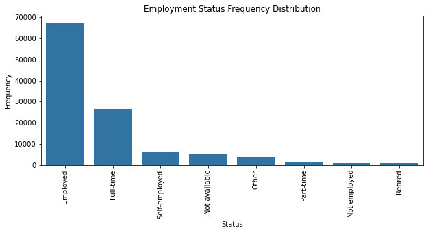

```python
#Employment Status
drawCountPlot('EmploymentStatus', 'Employment Status Frequency Distribution', 'Status')
```

The plot shows that most likely that Employees get loan, and the not employed, part time and retired rarly get loans.

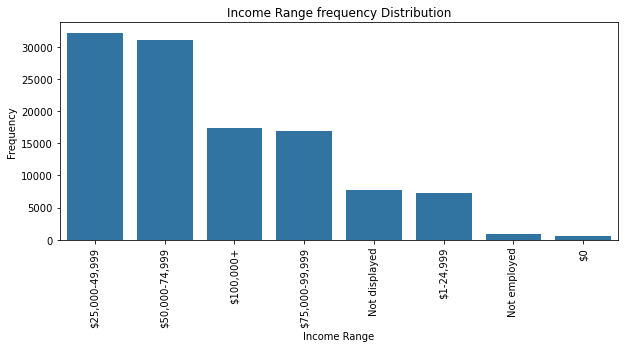

```python
#Income Range
drawCountPlot('IncomeRange', 'Income Range frequency Distribution', 'Income Range')
```

The plot shows that our data distribution for the income ranges from $\$$0 to $\$$100,000. Also, the most bin is $\$$25,000 to $\$$75,000.

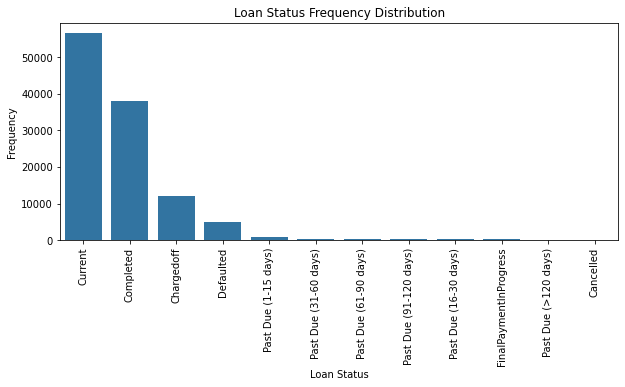

```python
#Loan Status
drawCountPlot('LoanStatus', 'Loan Status Frequency Distribution', 'Loan Status')
```

The plot shows that more than 50,000 individuals has a loan with Prosper, and quite a number has completed the loan.

```python
# Check the percentage of loans in each status
pct_loans_by_status = pd.DataFrame(df.groupby('LoanStatus')['LoanStatus'].count())
pct_loans_by_status['PctLoans'] = (pct_loans_by_status['LoanStatus']/pct_loans_by_status['LoanStatus'].sum())*100
pct_loans_by_status.sort_values(by='PctLoans', ascending=False)
```

| LoanStatus | LoanStatus | PctLoans |
| --- | --- | --- |
| Current | 56576 | 49.655511 |
| Completed | 38074 | 33.416713 |
| Chargedoff | 11992 | 10.525115 |
| Defaulted | 5018 | 4.404188 |
| Past Due (1-15 days) | 806 | 0.707408 |
| Past Due (31-60 days) | 363 | 0.318597 |
| Past Due (61-90 days) | 313 | 0.274713 |
| Past Due (91-120 days) | 304 | 0.266814 |
| Past Due (16-30 days) | 265 | 0.232585 |
| FinalPaymentInProgress | 205 | 0.179924 |
| Past Due (>120 days) | 16 | 0.014043 |
| Cancelled | 5 | 0.004388 |

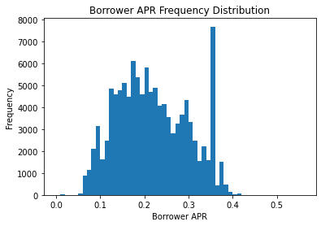

```python
#Borrower APR
bins = np.arange(0, df.BorrowerAPR.max()+0.05, 0.01)
plt.hist(data = df, x = 'BorrowerAPR', bins = bins, color = color);

plt.title('Borrower APR Frequency Distribution');
plt.xlabel('Borrower APR');
plt.ylabel('Frequency');
```

The distribution of APR looks multimodal. A small peak centered at 0.1, a large peak centered at 0.2. There is also a small peak centered 0.3. Additionally, there is a very shape peak between 0.35 and 0.36. Only very few loans have APR greater than 0.43.

Check loans with APR greater than 0.43

```python
df[keys][df.BorrowerAPR>0.43]
```

|  | LoanOriginalAmount | BorrowerAPR | StatedMonthlyIncome | Term | ProsperRating (Alpha) | EmploymentStatus |
| --- | --- | --- | --- | --- | --- | --- |
| 18326 | 3000 | 0.45857 | 10000.000000 | 36 | NaN | NaN |
| 22195 | 1789 | 0.46201 | 2916.666667 | 36 | NaN | NaN |
| 36018 | 1500 | 0.51229 | 2838.000000 | 36 | NaN | NaN |
| 56761 | 3000 | 0.50633 | 0.000000 | 36 | NaN | NaN |
| 82043 | 3000 | 0.48873 | 1583.333333 | 36 | NaN | NaN |
| 103973 | 2800 | 0.45857 | 3750.000000 | 36 | NaN | NaN |

There are 6 people with Borrower APR greater than 0.43, and their emplyment status are null.

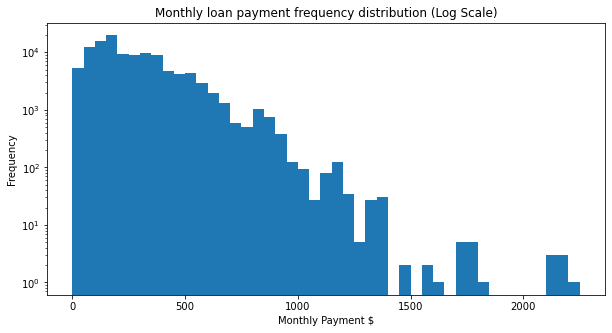

```python
#Monthly Loan Payment
plt.figure(figsize=[10, 5]);
bins = np.arange(0,df['MonthlyLoanPayment'].value_counts().index.max(),50)
plt.hist(data = df, x = 'MonthlyLoanPayment', bins = bins);

plt.title('Monthly loan payment frequency distribution (Log Scale)');
plt.xlabel('Monthly Payment $');
plt.ylabel('Frequency');
plt.yscale('log');
```

The plot is skewed to the right. Most of the people have monthly payment less than $\$$1000.

```python
# Decode ListingCategory (numeric) feature
list_dict = {0 : 'Not Available', 1 : 'Debt Consolidation', 2 : 'Home Improvement', 3: 'Business',
             4 : 'Personal Loan', 5 : 'Student Use', 6 : 'Auto', 7 : 'Other', 8 : 'Baby&Adoption',
             9 : 'Boat', 10 : 'Cosmetic Procedure', 11 : 'Engagement Ring', 12 : 'Green Loans',
             13 : 'Household Expenses', 14 : 'Large Purchases', 15 : 'Medical/Dental', 16 : 'Motorcycle',
             17 : 'RV', 18 : 'Taxes', 19 : 'Vacation', 20 : 'Wedding Loans'}

df['ListingCategory'] = df['ListingCategory (numeric)'].map(list_dict)
```

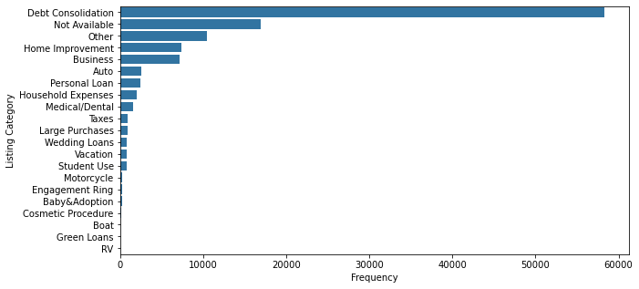

```python
plt.figure(figsize=[10, 5])
order = df['ListingCategory'].value_counts().index

sb.countplot(data = df, y = 'ListingCategory', color = color, order = order)
plt.ylabel('Listing Category')
plt.xlabel('Frequency');
```

### Discuss the distribution(s) of your variable(s) of interest. Were there any unusual points? Did you need to perform any transformations?

The distribution of borrowers APR looks multimodal. Most of the values are at the range of 0.05 and 0.4. There are no unusual points and no need to perform any transformations.  
It also appears that most of the creditors of Prosper have loans for debt consolidation.

### Of the features you investigated, were there any unusual distributions? Did you perform any operations on the data to tidy, adjust, or change the form of the data? If so, why did you do this?

1- Listing Categories:
It indicates that most of Prosper loans are debt consolidation. And, its followed by not available and other kinds of loans, indicating that Prosper should do a better job to correctly classify its loans.
2- Monthly Loan Payment:
Most of the people have monthly payment less than $\$$1000.
3- There are 6 people with Borrower APR greater than 0.43, and their emplyment status are null.

## Bivariate Exploration

Firstly, I will look at the pairwise correlations present between features in the data.

```python
numeric = ['ProsperScore', 'EmploymentStatusDuration', 'OpenRevolvingAccounts', 'CurrentCreditLines', 'DebtToIncomeRatio', 'LoanOriginalAmount']
categoric = ['LoanStatus', 'ListingCategory','EmploymentStatus', 'IncomeVerifiable']
```

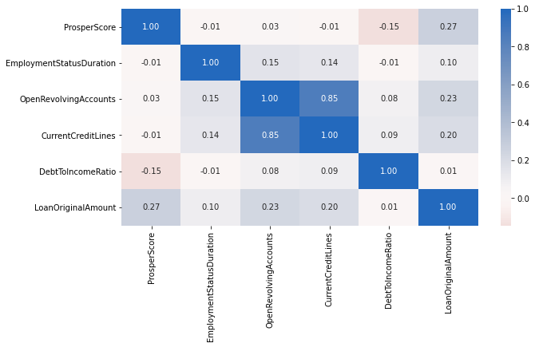

```python
#heatmap
plt.figure(figsize = [10, 5])
sb.heatmap(df[numeric].corr(), annot = True, fmt = '.2f', cmap = 'vlag_r', center = 0)
plt.show()
```

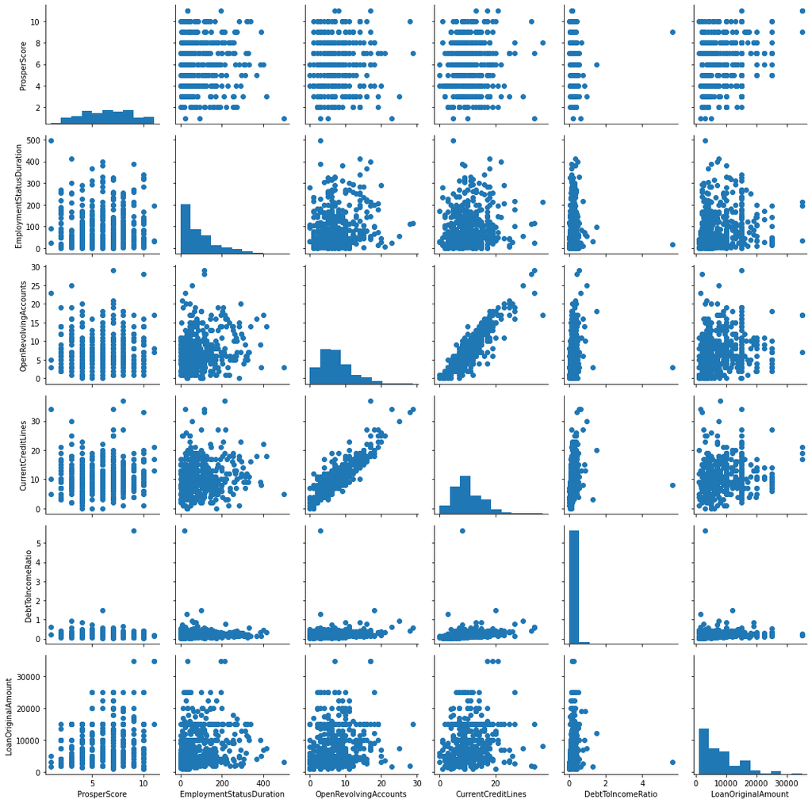

```python
#scatter
samples = np.random.choice(df.shape[0], 500, replace = False)
loan_samples = df.loc[samples, numeric]

g = sb.PairGrid(data = loan_samples, vars = numeric)
g = g.map_diag(plt.hist)
g.map_offdiag(plt.scatter);
```

The CurrentCreditLines and OpenRevolvingAccounts dimensions are all highly correlated with one another.

```python
#Yearly Borrower Rates
df['year'] = df['ListingCreationDate'].astype(str).str[:4]
```

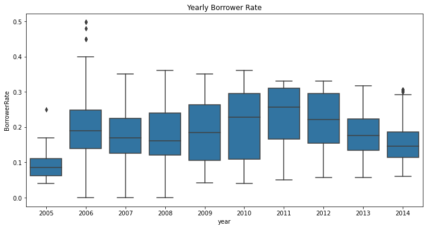

```python
plt.figure(figsize=[12, 6]);
sb.boxplot(data = df, x = 'year', y = 'BorrowerRate', color = color,
    order = ['2005' ,  '2006', '2007', '2008', '2009', '2010', '2011', '2012', '2013', '2014']);
plt.title('Yearly Borrower Rate');
```

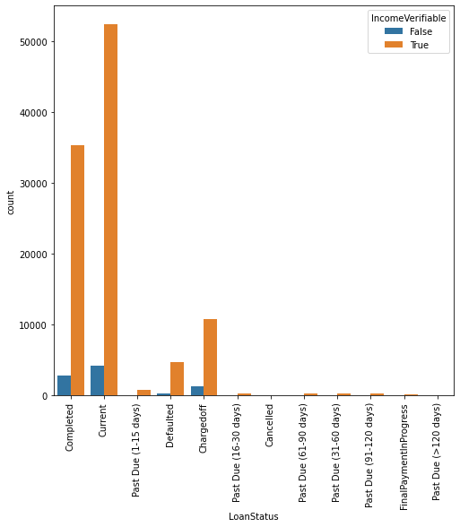

```python
# LoanStatus vs IncomeVerifiable
plt.figure(figsize = [8, 8])

sb.countplot(data = df, x = 'LoanStatus', hue = 'IncomeVerifiable')
plt.xticks(rotation=90);
```

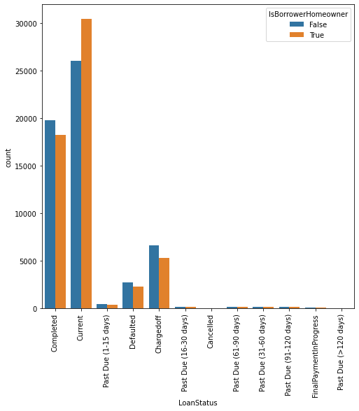

```python
# LoanStatus vs IsBorrowerHomeOwner
plt.figure(figsize = [8, 8])

sb.countplot(data = df, x = 'LoanStatus', hue = 'IsBorrowerHomeowner')
plt.xticks(rotation=90);
```

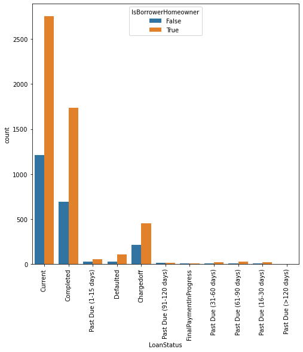

```python
# LoanStatus vs IsBorrowerHomeOwner for Home Improvement loans
plt.figure(figsize = [8, 8])

sb.countplot(data = df[df['ListingCategory'] == 'Home Improvement'], x = 'LoanStatus', hue = 'IsBorrowerHomeowner')
plt.xticks(rotation=90);
```

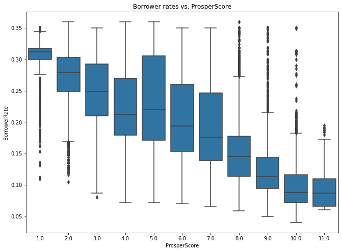

```python
plt.figure(figsize=[11, 8]);
base_color = sb.color_palette()[3];
sb.boxplot(data = df, x = 'ProsperScore', y = 'BorrowerRate', color = color);
plt.title('Borrower rates vs. ProsperScore');
```

The plot show a strong relation between the score factor and borrower's rate. We see that the higher the score, the lower the rate.

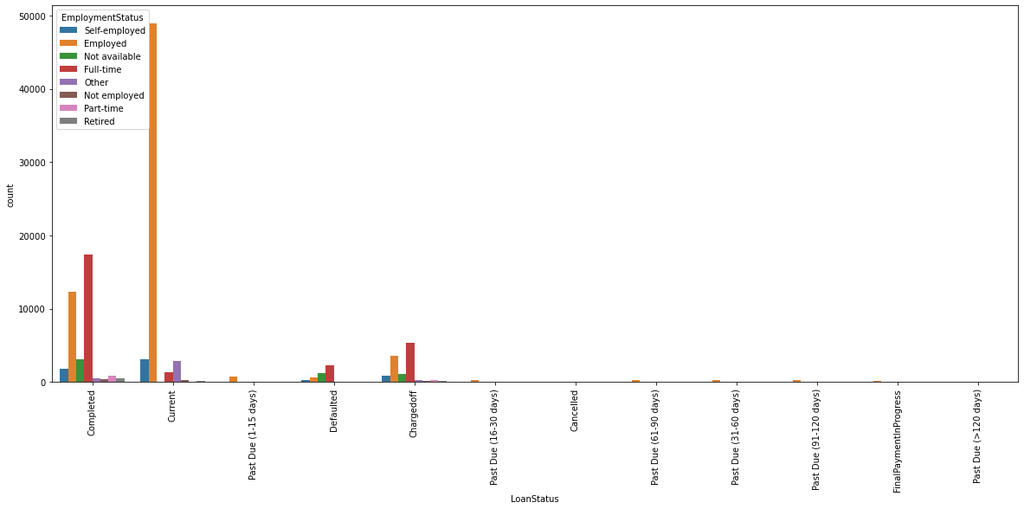

```python
# LoanStatus vs EmploymentStatus
plt.figure(figsize = [20, 8])

sb.countplot(data = df, x = 'LoanStatus', hue = 'EmploymentStatus');
plt.xticks(rotation=90);
```

The plot shows borrowers who are employed and have full-time jobs have most of the defaulted and charged-off loans.

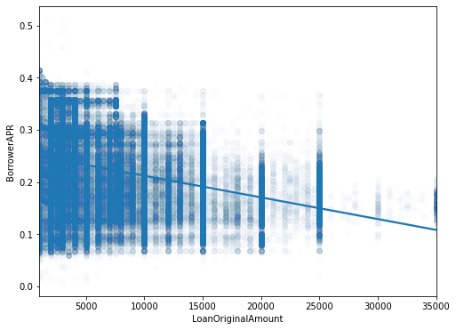

```python
plt.figure(figsize = [8, 6])
sb.regplot(data = df, x = 'LoanOriginalAmount', y = 'BorrowerAPR', scatter_kws={'alpha':0.01});
```

The plot show that at different size of the loan amount, the APR has a large range, but the range of APR decrease with the increase of loan amount.

### Talk about some of the relationships you observed in this part of the investigation. How did the feature(s) of interest vary with other features in the dataset?

The CurrentCreditLines and OpenRevolvingAccounts dimensions are all highly correlated with one another.  
The plot show a strong relation between the score factor and borrower's rate. The higher the score, the lower the rate.  
The borrowers who are employed and have full-time jobs have most of the defaulted and charged-off loans.  
There is negative relation between borrower APR and loan amount.

## Multivariate Exploration

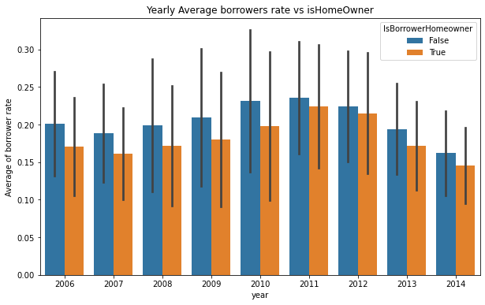

```python
# Yearly Average borrowers rate vs isHomeOwner
plt.figure(figsize=[10, 6]);
sb.barplot(data = df, x = 'year', y = 'BorrowerRate', hue = 'IsBorrowerHomeowner', ci = 'sd',
    order = [ '2006', '2007', '2008', '2009', '2010', '2011', '2012', '2013', '2014']);
plt.ylabel('Average of borrower rate');
plt.title('Yearly Average borrowers rate vs isHomeOwner');
```

The plot conclude that people who owns homes have lower rate than doesn't.

[figure not shown]

```python
# BorrowerAPR vs. CreditScoreRangeUpper & ProsperScore

plt.figure(figsize = [15, 5])

def draw(side, title):
    plt.subplot(1, 2, side)
    if(side==1):
        plt.scatter(data = df, x = 'CreditScoreRangeUpper', y = 'BorrowerAPR', alpha = 0.5)
    else:
        plt.scatter(data = df, x = 'CreditScoreRangeUpper', y = 'BorrowerAPR', c ='ProsperScore', alpha = 0.5)
        plt.colorbar(label = 'ProsperScore')
    plt.title(title)
    plt.xlabel('BorrowerAPR')
    plt.ylabel('CreditScoreRangeUpper')

draw(1, 'BorrowerAPR vs. CreditScoreRangeUpper')
draw(2, 'BorrowerAPR vs. CreditScoreRangeUpper & CreditScoreRangeUpper')
```

There are negative correlation between CreditScoreRangeUpper and BorrowerAPR. And Also from the right-side plot, ProsperScore has negative correlation with BorrowAPR.

### Were there any interesting or surprising interactions between features?

From all above visualizations created from univariate exploration to multivariate exploration, many variable are found to be negatively correlated to BorrowerAPR, whereas ProspoerScore gives the strongest negative relationship.